# SIG16 ATAC: TF motif enrichment in differentially accessible regions

EYW

2026-09-26

```r
suppressPackageStartupMessages({
  library(tidyverse)
  library(patchwork)
})
knitr::opts_chunk$set(echo = TRUE)

source("../../functions/r_custom/plotting_fxns.R")
theme_set(theme_Publication())

set.seed(1)

idr <- 0.05
job.name <- paste0("idr-", idr)

DESEQ_DIR <- file.path("../../analysis_outs", "deseq2-merged-reps", job.name)
OUT_DIR   <- file.path("../../analysis_outs",
                       "motif_enrichment-hypergeometric-merged-reps", job.name)
PLOT_DIR  <- file.path("../../analysis_outs", "plots",
                       "motif_enrichment-hypergeometric-merged-reps")

dir.create(OUT_DIR, recursive = TRUE, showWarnings = FALSE)
dir.create(PLOT_DIR, recursive = TRUE, showWarnings = FALSE)

padj.threshold <- 0.05
lfc.threshold  <- log2(1.5)
```

# Goal

Ask which TF motifs are over-represented in each set of differentially accessible regions, reproducing `ATAC-analysis/SIG16_ATAC/3-motif-enrichment.R`.

The test is a one-sided hypergeometric test per motif: given the number of atlas peaks containing a FIMO hit for that motif, how surprising is the number of hits inside the region set of interest? Fold enrichment is the hit rate in the region set over the hit rate across the whole atlas, and p-values are BH-adjusted across motifs within each region set.

Seventeen region sets are tested:

- **8 single-ligand sets** — gained / lost peaks for each of TGFb, IL4, IL6, TNF.
- **9 interaction sets** — the three SIG13 interaction classes (`synergy positive`, `synergy negative`, `buffering`) for each of the three `ligand1 x TNF` pairs, taken from `03_interaction_classification.Rmd`.

Splitting the interaction peaks by class rather than by the sign of the interaction coefficient is the point of this notebook: `synergy positive` and `synergy negative` peaks both have a same-signed interaction term but move in opposite directions overall, so the motifs driving them should differ. `buffering` peaks are the ones where the second ligand blunts the first.

> Note: the collaborator’s script tested TGFb, IL4 and TNF singles plus the TGFb x TNF and IL4 x TNF interactions, split only on the sign of the interaction coefficient. IL6 is included here as well, since the corresponding DESeq2 and interaction-classification results exist.

# Import

`motif_mtx.rds` is a peaks x motifs binary matrix of FIMO hits over the same atlas; `motif_info.rds` maps each motif to its TF and structural family.

```r
motif.mtx.peak.final <- readRDS(file.path("../../analysis_outs/fimo", job.name, "motif_mtx.rds"))
colnames(motif.mtx.peak.final) <- stringr::str_split_i(colnames(motif.mtx.peak.final), "_[A-Z]", 1)

motif.info <- readRDS("../../analysis_outs/motif_info.rds")
pal <- readRDS("../../analysis_outs/plots/pal_family.rds")

dim(motif.mtx.peak.final)
```

```
## [1] 63218   787
```

```r
read_single <- function(term) {
  readRDS(file.path(DESEQ_DIR, paste0("name-", term), "unshrunken-res.table.rds"))
}
# interaction-classification.csv carries the SIG13 schema: `name` + `interaction_class`
read_itxn <- function(l1, l2 = "TNF") {
  df <- read.csv(file.path(DESEQ_DIR, paste0("name-ligand1", l1, ".ligand2", l2),
                           "interaction-classification.csv"))
  rownames(df) <- df$name
  df
}

singles <- list(TGFb = read_single("ligand1_TGFb_vs_none"),
                IL4  = read_single("ligand1_IL4_vs_none"),
                IL6  = read_single("ligand1_IL6_vs_none"),
                TNF  = read_single("ligand2_TNF_vs_none"))

itxns <- list(TGFb.TNF = read_itxn("TGFb"),
              IL4.TNF  = read_itxn("IL4"),
              IL6.TNF  = read_itxn("IL6"))
```

# Define region sets

```r
split_by_lfc <- function(df, lfc.col, padj.col) {
  keep <- !is.na(df[[padj.col]]) & df[[padj.col]] < padj.threshold
  list(pos = df[keep & df[[lfc.col]] >  lfc.threshold, ],
       neg = df[keep & df[[lfc.col]] < -lfc.threshold, ])
}

itxn.classes <- c("synergy positive", "synergy negative", "buffering")
set_name <- function(prefix, cl) paste0(prefix, ".", gsub(" ", "_", cl))

regions <- list()
for (nm in names(singles)) {
  s <- split_by_lfc(singles[[nm]], "log2FoldChange", "padj")
  regions[[paste0(nm, ".gained")]] <- s$pos
  regions[[paste0(nm, ".lost")]]   <- s$neg
}
for (nm in names(itxns)) {
  for (cl in itxn.classes) {
    peaks <- itxns[[nm]][!is.na(itxns[[nm]]$interaction_class) &
                           itxns[[nm]]$interaction_class == cl, ]
    rownames(peaks) <- peaks$name   # the enrichment test matches peaks on rownames
    regions[[set_name(nm, cl)]] <- peaks
  }
}

tibble(region = names(regions), n_peaks = map_int(regions, nrow))
```

```
## # A tibble: 17 × 2
##    region                    n_peaks
##    <chr>                       <int>
##  1 TGFb.gained                  1230
##  2 TGFb.lost                      71
##  3 IL4.gained                   3294
##  4 IL4.lost                     2830
##  5 IL6.gained                    507
##  6 IL6.lost                      169
##  7 TNF.gained                   3861
##  8 TNF.lost                     1266
##  9 TGFb.TNF.synergy_positive      54
## 10 TGFb.TNF.synergy_negative       0
## 11 TGFb.TNF.buffering              1
## 12 IL4.TNF.synergy_positive       53
## 13 IL4.TNF.synergy_negative       81
## 14 IL4.TNF.buffering             515
## 15 IL6.TNF.synergy_positive        6
## 16 IL6.TNF.synergy_negative        1
## 17 IL6.TNF.buffering              10
```

# Hypergeometric enrichment

```r
# One-sided hypergeometric test per motif: of the `all_peaks` in the atlas,
# `matches_in_all_peaks` carry the motif; ask whether the `DARs` in this region set
# carry it more often than that background rate.
hypergeom.res.list <- compact(imap(regions, function(input.regions, region.name) {
  if (nrow(input.regions) == 0) return(NULL)

  peak.pos <- match(rownames(input.regions), rownames(motif.mtx.peak.final))
  n.all <- nrow(motif.mtx.peak.final)
  n.dar <- length(peak.pos)

  res <- imap_dfr(motif.mtx.peak.final, function(hits, motif) {
    hits.all  <- sum(hits)
    hits.dar  <- sum(hits[peak.pos])
    tibble(motif = motif,
           pval = phyper(hits.dar - 1, hits.all, n.all - hits.all, n.dar,
                         lower.tail = FALSE),
           fold_enrichment = (hits.dar / n.dar) / (hits.all / n.all),
           matches_in_DARs = hits.dar, DARs = n.dar,
           matches_in_all_peaks = hits.all, all_peaks = n.all)
  }) %>%
    arrange(pval) %>%
    mutate(p.adjust = p.adjust(pval, method = "BH"), .after = pval) %>%
    relocate(motif, .after = all_peaks) %>%
    as.data.frame()
  rownames(res) <- res$motif

  res$family <- motif.info[match(rownames(res), motif.info$TF), "family"]
  write.csv(res, file.path(OUT_DIR, paste0(region.name, ".csv")), quote = FALSE)
  res
}))
```

```r
padj.cutoff <- 0.05
fe.cutoff   <- 1.5
k <- 10

map_dfr(hypergeom.res.list, ~ tibble(
  n_motifs_tested = nrow(.x),
  n_significant = sum(.x$p.adjust < padj.cutoff & .x$fold_enrichment > fe.cutoff, na.rm = TRUE)
), .id = "region") %>%
  left_join(tibble(region = names(regions), n_peaks = map_int(regions, nrow)), by = "region") %>%
  relocate(n_peaks, .after = region)
```

```
## # A tibble: 16 × 4
##    region                    n_peaks n_motifs_tested n_significant
##    <chr>                       <int>           <int>         <int>
##  1 TGFb.gained                  1230             787            13
##  2 TGFb.lost                      71             787             0
##  3 IL4.gained                   3294             787            27
##  4 IL4.lost                     2830             787            51
##  5 IL6.gained                    507             787            30
##  6 IL6.lost                      169             787             8
##  7 TNF.gained                   3861             787            14
##  8 TNF.lost                     1266             787            26
##  9 TGFb.TNF.synergy_positive      54             787             7
## 10 TGFb.TNF.buffering              1             787             0
## 11 IL4.TNF.synergy_positive       53             787             7
## 12 IL4.TNF.synergy_negative       81             787             3
## 13 IL4.TNF.buffering             515             787             8
## 14 IL6.TNF.synergy_positive        6             787             0
## 15 IL6.TNF.synergy_negative        1             787             0
## 16 IL6.TNF.buffering              10             787             0
```

# Top-motif bar plots

Top 10 motifs by fold enrichment, among motifs passing `p.adjust < 0.05` and fold enrichment > 1.5, coloured by TF structural family.

```r
top_motifs <- function(res, k = 10) {
  sig.tf <- res[(res$p.adjust < padj.cutoff) & (res$fold_enrichment > fe.cutoff), ]
  sig.tf <- sig.tf %>% arrange(desc(fold_enrichment))
  sig.tf <- sig.tf[seq_len(min(k, nrow(sig.tf))), ]
  sig.tf[!is.na(sig.tf$pval), ]
}

plot_bar <- function(sig.tf, region.name) {
  ggplot(sig.tf) +
    geom_col(aes(x = fold_enrichment, y = reorder(motif, fold_enrichment), fill = family)) +
    theme(axis.text.y = element_text(size = 12), axis.title.y = element_blank()) +
    labs(title = region.name, x = "fold enrichment") +
    scale_fill_manual(values = pal$family) +
    theme(aspect.ratio = 2)
}
```

```r
bar.plots <- list()
for (region.name in names(hypergeom.res.list)) {
  sig.tf <- top_motifs(hypergeom.res.list[[region.name]], k)
  cat("\n## ", region.name, " (", nrow(sig.tf), " motifs shown)\n", sep = "")
  if (nrow(sig.tf) == 0) { cat("No motifs pass the enrichment cutoffs.\n"); next }
  bar.plots[[region.name]] <- plot_bar(sig.tf, region.name)
}
```

## TGFb.gained (10 motifs shown)

## TGFb.lost (0 motifs shown)

No motifs pass the enrichment cutoffs.

## IL4.gained (10 motifs shown)

## IL4.lost (10 motifs shown)

## IL6.gained (10 motifs shown)

## IL6.lost (8 motifs shown)

## TNF.gained (10 motifs shown)

## TNF.lost (10 motifs shown)

## TGFb.TNF.synergy_positive (7 motifs shown)

## TGFb.TNF.buffering (0 motifs shown)

No motifs pass the enrichment cutoffs.

## IL4.TNF.synergy_positive (7 motifs shown)

## IL4.TNF.synergy_negative (3 motifs shown)

## IL4.TNF.buffering (8 motifs shown)

## IL6.TNF.synergy_positive (0 motifs shown)

No motifs pass the enrichment cutoffs.

## IL6.TNF.synergy_negative (0 motifs shown)

No motifs pass the enrichment cutoffs.

## IL6.TNF.buffering (0 motifs shown)

No motifs pass the enrichment cutoffs.

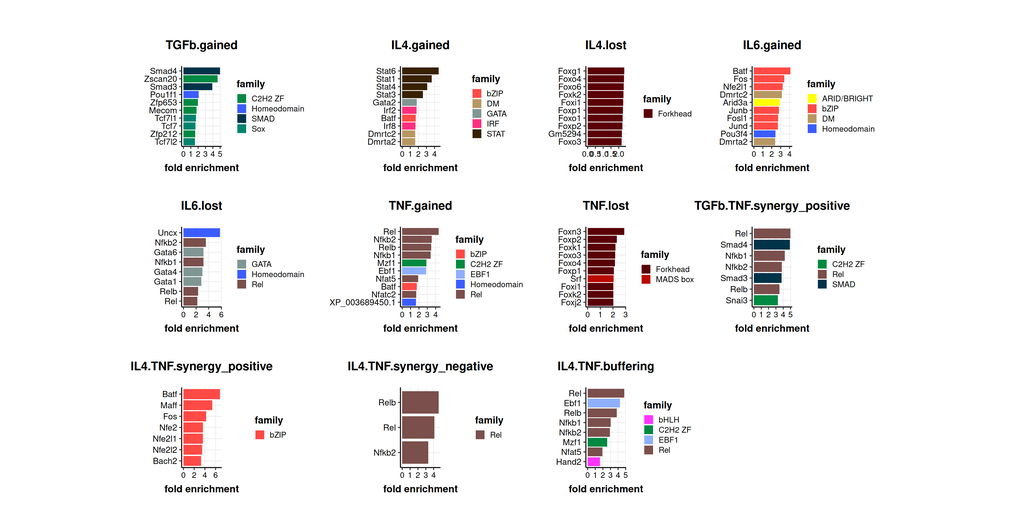

```r
n.col <- 4
n.row <- ceiling(length(bar.plots) / n.col)
wrap_plots(bar.plots, ncol = n.col) +
  plot_layout() &
  theme(legend.position = "right")
```

```r
ggsave(file.path(PLOT_DIR, paste0("barplots-top", k, "-motifs-padj-", padj.cutoff, ".pdf")))
```

# Bi-directional bar plots

Two opposing region sets on one axis; bar length is fold enrichment in either direction. For the single ligands the pair is gained (right) vs lost (left); for the interactions it is `synergy positive` (right) vs `synergy negative` (left). The `buffering` sets have no natural opposite and appear only in the uni-directional plots above.

```r
bidirectional_pairs <- tibble::tribble(
  ~label,     ~pos,                        ~neg,                        ~pos.lab,           ~neg.lab,
  "TGFb",     "TGFb.gained",               "TGFb.lost",                 "gained",           "lost",
  "IL4",      "IL4.gained",                "IL4.lost",                  "gained",           "lost",
  "IL6",      "IL6.gained",                "IL6.lost",                  "gained",           "lost",
  "TNF",      "TNF.gained",                "TNF.lost",                  "gained",           "lost",
  "TGFb.TNF", "TGFb.TNF.synergy_positive", "TGFb.TNF.synergy_negative", "synergy positive", "synergy negative",
  "IL4.TNF",  "IL4.TNF.synergy_positive",  "IL4.TNF.synergy_negative",  "synergy positive", "synergy negative",
  "IL6.TNF",  "IL6.TNF.synergy_positive",  "IL6.TNF.synergy_negative",  "synergy positive", "synergy negative")

plot_bidirectional <- function(pair) {
  sig.tf.pos <- top_motifs(hypergeom.res.list[[pair$pos]], k)
  sig.tf.neg <- top_motifs(hypergeom.res.list[[pair$neg]], k)
  if (!is.null(sig.tf.neg)) sig.tf.neg$fold_enrichment <- sig.tf.neg$fold_enrichment * -1

  sig.tf <- rbind(sig.tf.pos, sig.tf.neg)
  if (is.null(sig.tf) || nrow(sig.tf) == 0) return(NULL)

  sig.tf <- sig.tf %>% arrange(fold_enrichment)
  sig.tf$rank <- factor(seq_len(nrow(sig.tf)), levels = seq_len(nrow(sig.tf)))

  annotations <- data.frame(
    xpos = c(-Inf, Inf),
    ypos = c(-Inf, -Inf),
    annotateText = c(pair$neg.lab, pair$pos.lab),
    hjustvar = c(0, 1.1),
    vjustvar = c(-0.5, -0.5))

  bar.p <- ggplot(sig.tf) +
    geom_col(aes(x = fold_enrichment, y = rank, fill = family)) +
    theme(axis.text.y = element_text(size = 12), axis.title.y = element_blank()) +
    #scale_x_continuous(breaks = seq(-10, 10, 1), labels = abs(seq(-10, 10, 1))) +
    # extra room at the bottom so the direction labels clear the last bar
    scale_y_discrete(labels = sig.tf$motif, expand = expansion(add = c(1.2, 0.6))) +
    scale_fill_manual(values = pal$family) +
    labs(title = pair$label, x = "fold enrichment") +
    geom_text(data = annotations,
              aes(x = xpos, y = ypos, hjust = hjustvar, vjust = vjustvar,
                  label = annotateText)) +
    theme(aspect.ratio = 2)
  bar.p
}
```

```r
bidir.plots <- list()
for (i in seq_len(nrow(bidirectional_pairs))) {
  pair <- as.list(bidirectional_pairs[i, ])
  cat("\n\n## ", pair$label, "\n\n", sep = "")
  if (!all(c(pair$pos, pair$neg) %in% names(hypergeom.res.list))) {
    cat("One or both region sets are empty; no plot.\n\n"); next
  }
  p <- plot_bidirectional(pair)
  if (is.null(p)) {
    cat("No motifs pass the enrichment cutoffs.\n\n")
  } else {
    bidir.plots[[pair$label]] <- p
    print(p)
  }
}
```

## TGFb

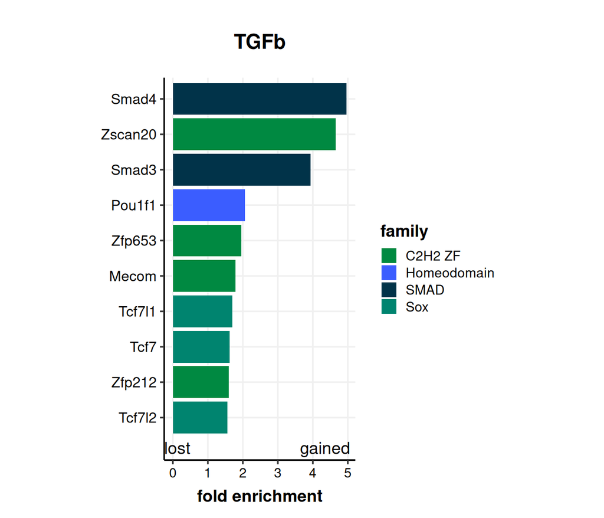

## IL4

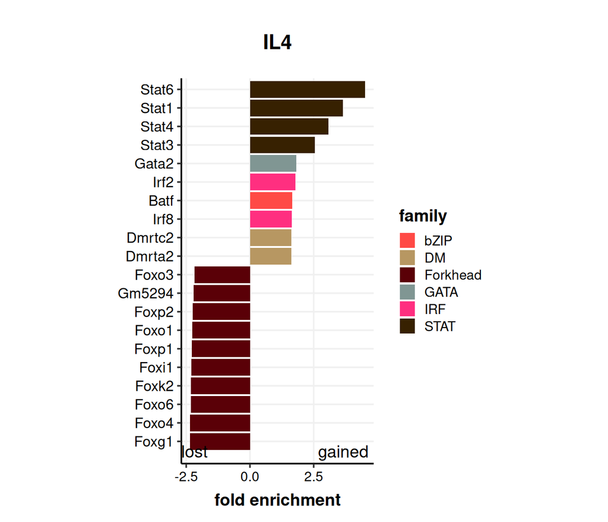

## IL6

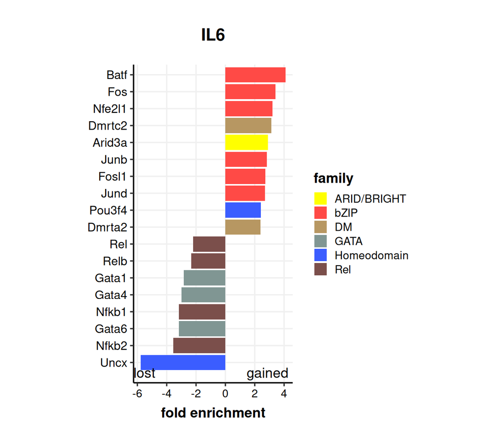

## TNF

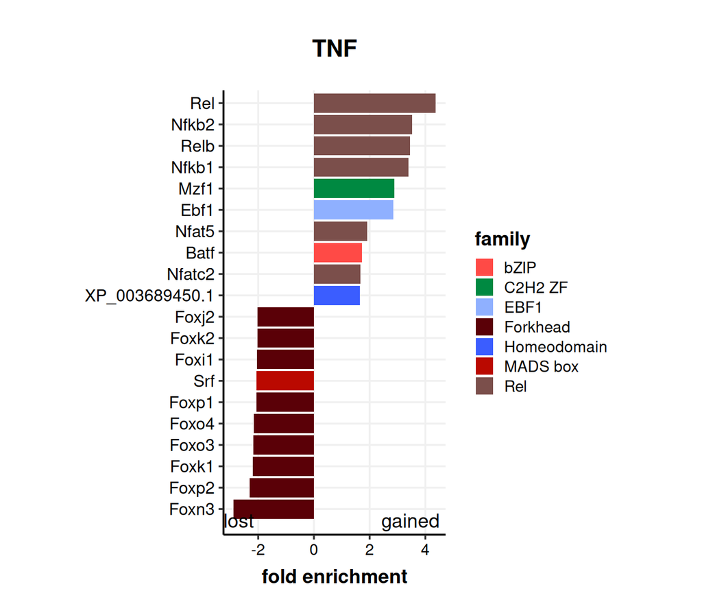

## TGFb.TNF

One or both region sets are empty; no plot.

## IL4.TNF

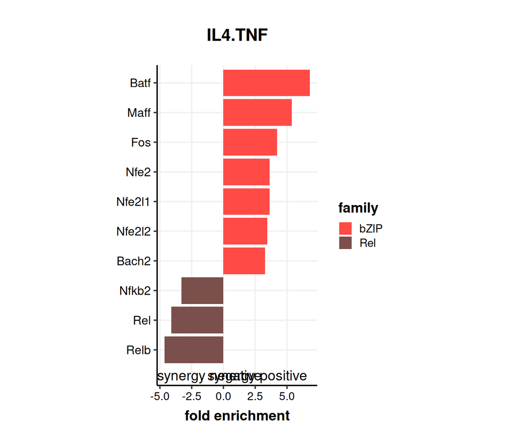

## IL6.TNF

No motifs pass the enrichment cutoffs.

```r
n.col <- 4
n.row <- ceiling(length(bidir.plots) / n.col)
bidir.panel <- wrap_plots(bidir.plots, ncol = n.col) +
  plot_layout(guides = "collect") &
  theme(legend.position = "right")

ggsave(file.path(PLOT_DIR,
                 paste0("barplots-bidirectional-top", k, "-motifs-padj-", padj.cutoff, ".pdf")),
       bidir.panel, width = 5 * n.col, height = 6 * n.row, limitsize = FALSE)
```